# Is a relation a function? And is the function one-to-one?

# Relation

- A relation associates some elements of one set (called the domain) with some elements of another set (called the range). There are many ways to express relations:
- Segments connecting elements of sets:

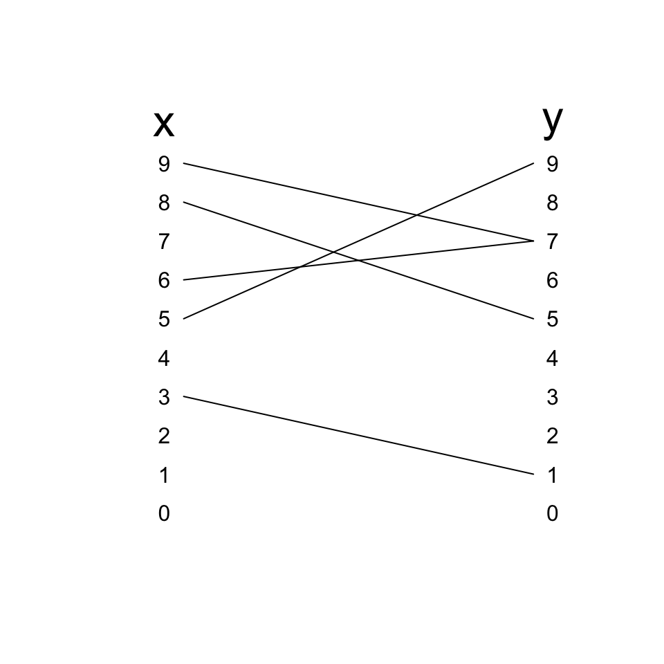

- A list of ordered pairs

$$( 3 , 1 )~~( 5 , 9 )~~( 6 , 7 )~~( 8
, 5 )~~( 9 , 7 )$$

- A plot of points

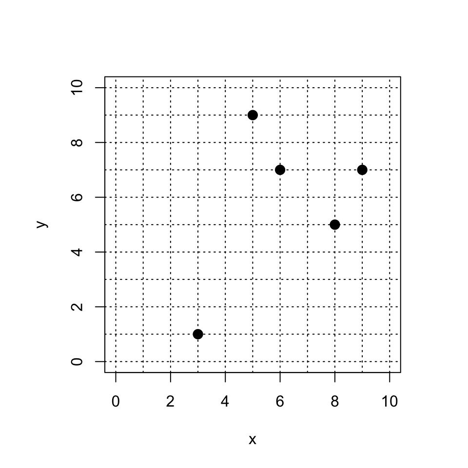

- In this case, the [domain](https://en.wikipedia.org/wiki/Domain_of_a_function) is {3, 5, 6, 8, 9}
- In this case, the [range](https://en.wikipedia.org/wiki/Range_of_a_function) is {1, 5, 7, 9}

# Is relation a function?

- We say $y$ is a function of $x$ if the relation passes the [vertical line test](https://en.wikipedia.org/wiki/Vertical_line_test).
- Let’s see an example that FAILS the vertical line test, thus meaning that $y$ is not a function of $x$.

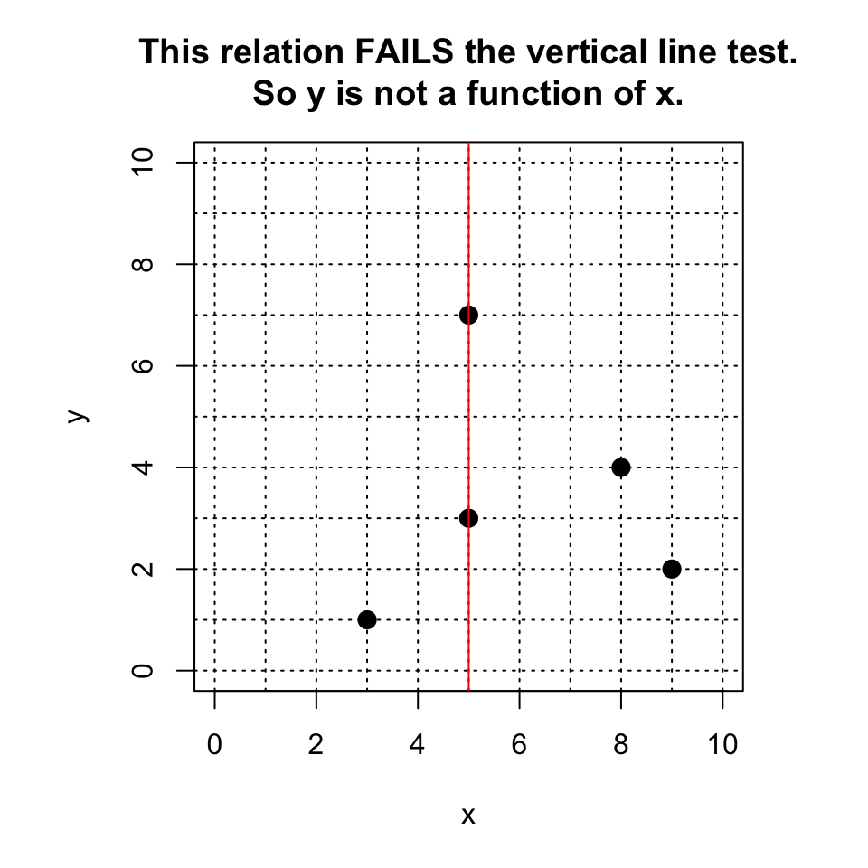

- Notice as ordered pairs, we see the same $x$ value (5) paired with two different $y$ values (3 and 7), and that indicated that $y$ is not a function of $x$.
  $$( 3 , 1 )~~( 5 , 3 )~~( 5 , 7 )~~( 8 , 4 )~~(
  9 , 2 )$$
- And we see $y$ is not a function of $x$ in set connections as a “v” shape in the left column.

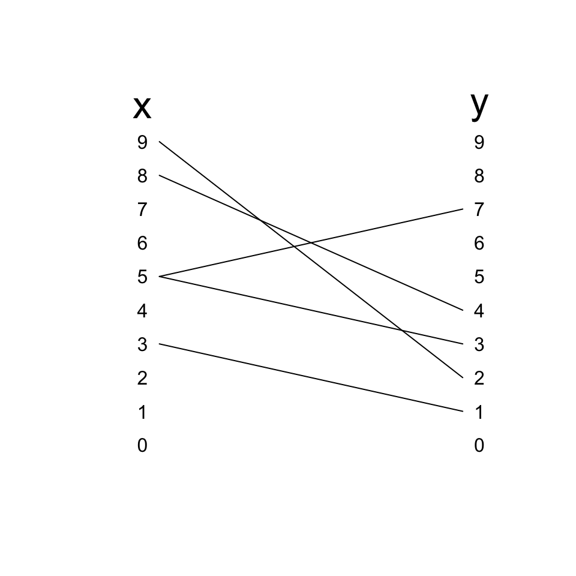

# Is reverse relation a function?

- We say $x$ is a function of $y$ if the relation passes the [horizontal line test](https://en.wikipedia.org/wiki/Horizontal_line_test).
- Let’s see an example that FAILS the horizontal line test, thus meaning that $x$ is not a function of $y$.

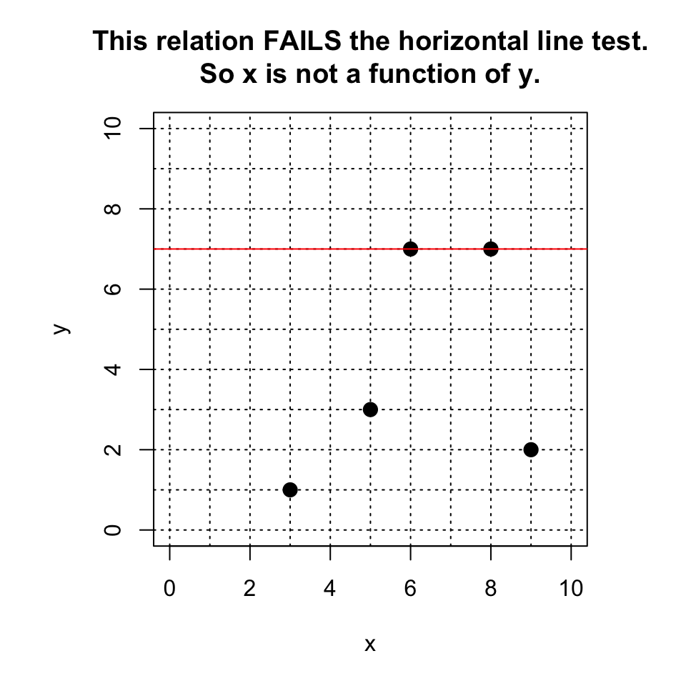

- Notice as ordered pairs, we see the same $y$ value (7) paired with two different $x$ values (6 and 8), and that indicated that $x$ is not a function of $y$.
  $$( 3 , 1 )~~( 5 , 3 )~~( 6 , 7 )~~( 8 , 7 )~~(
  9 , 2 )$$
- And we see $x$ is not a function of $y$ in set connections as a “v” shape in the right column.

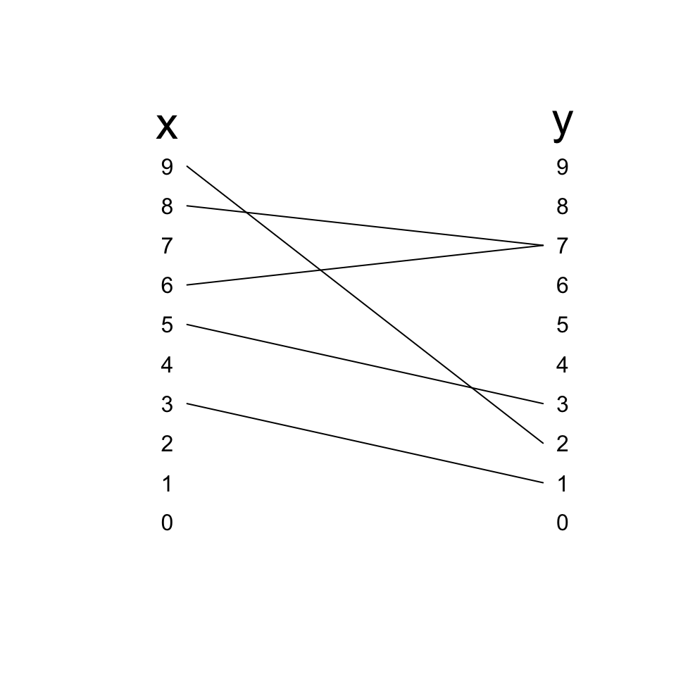

# Is the relation a one-to-one function?

- If:
  - $y$ is a function of $x$
  - AND
  - $x$ is a function of $y$
- Then the function is [one-to-one](https://en.wikipedia.org/wiki/Injective_function).

Here is an example of a one-to-one function:

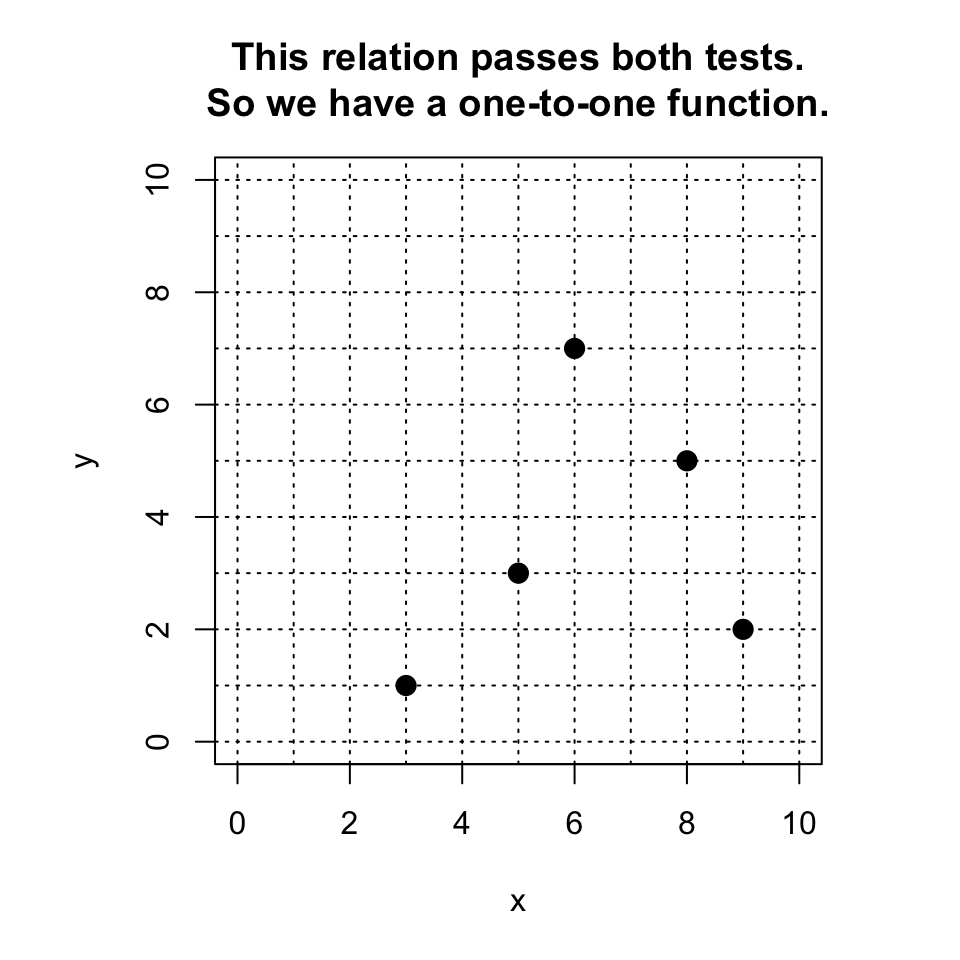

$$( 3 , 1 )~~( 5 , 3 )~~( 6 , 7 )~~( 8
, 5 )~~( 9 , 2 )$$

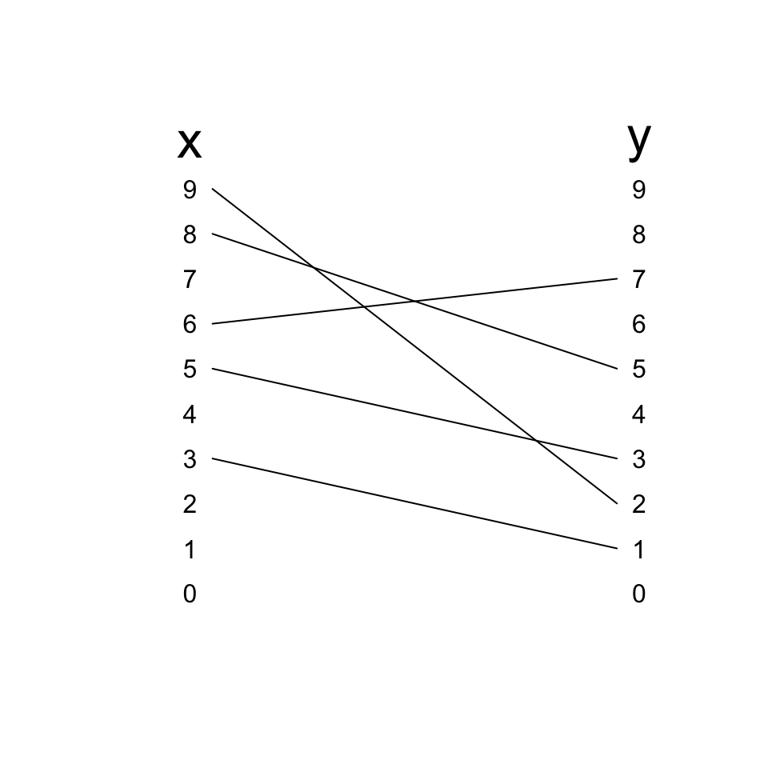

# A relation can be neither a function mapping $x$ to $y$ nor a function mapping $y$ to $x$.

- If:
  - $y$ is NOT a function of $x$
  - AND
  - $x$ is NOT a function of $y$
- Then the relation is not a function in either direction.

Here is an example:

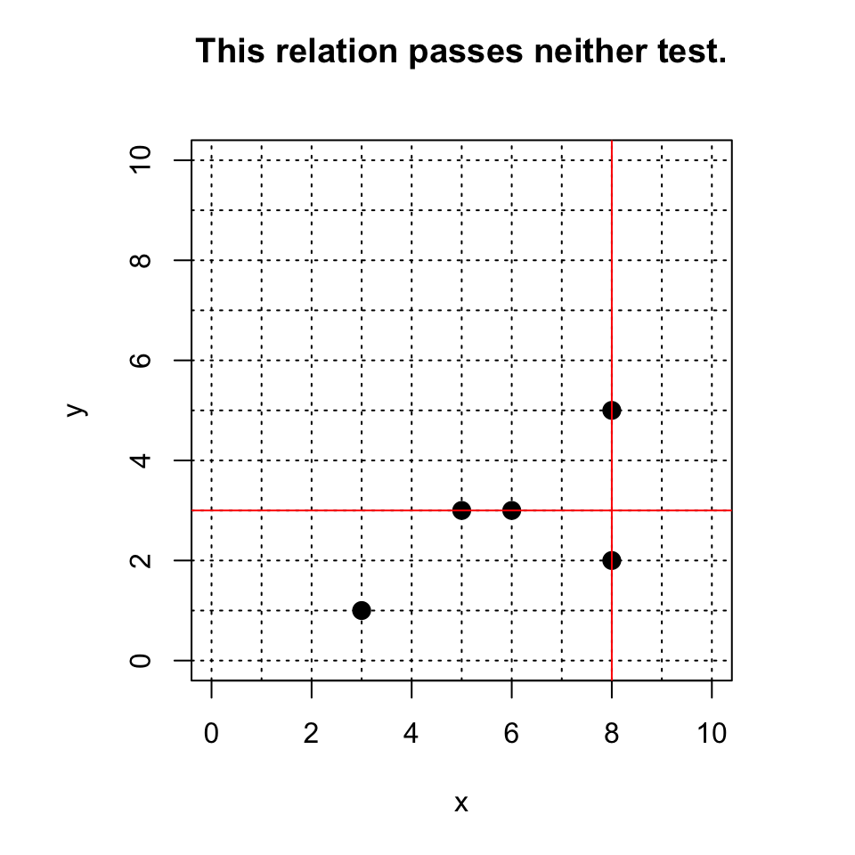

$$( 3 , 1 )~~( 5 , 3 )~~( 6 , 3 )~~( 8
, 5 )~~( 8 , 2 )$$

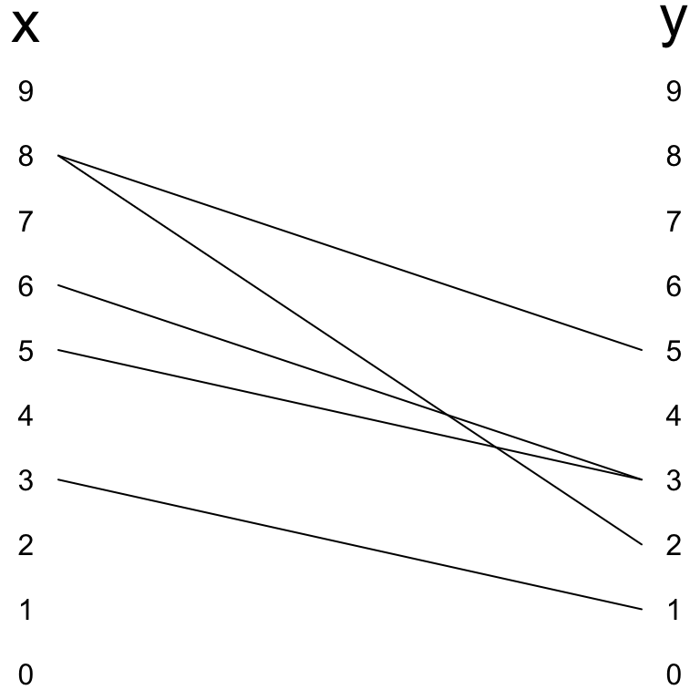

# We do

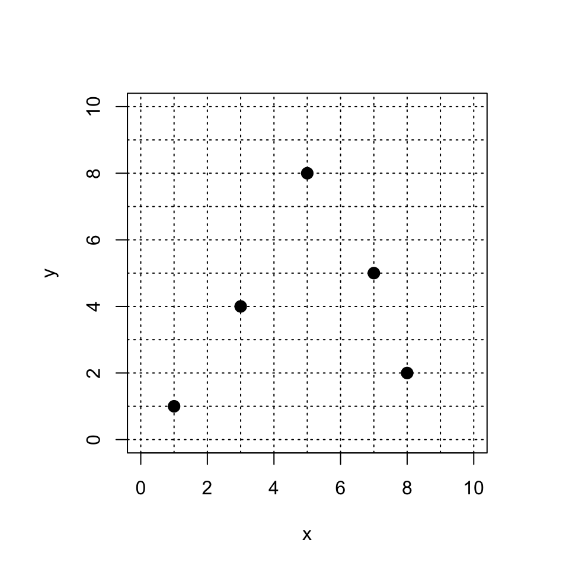

- Is $y$ a function of $x$? (Does it pass vertical line test?)
- Is $x$ a function of $y$? (Does it pass horizontal line test?)
- Is there a one-to-one function? (Does it pass both tests?)

# We do 2

A relation is expressed as a list of ordered $(x,y)$ pairs.

$$( 1 , 1 )~~( 3 , 4 )~~( 5 , 8 )~~( 5
, 8 )~~( 7 , 5 )~~( 8 , 4 )$$

- Is $y$ a function of $x$? (Does it pass vertical line test?)
- Is $x$ a function of $y$? (Does it pass horizontal line test?)
- Is there a one-to-one function? (Does it pass both tests?)

# We do 3

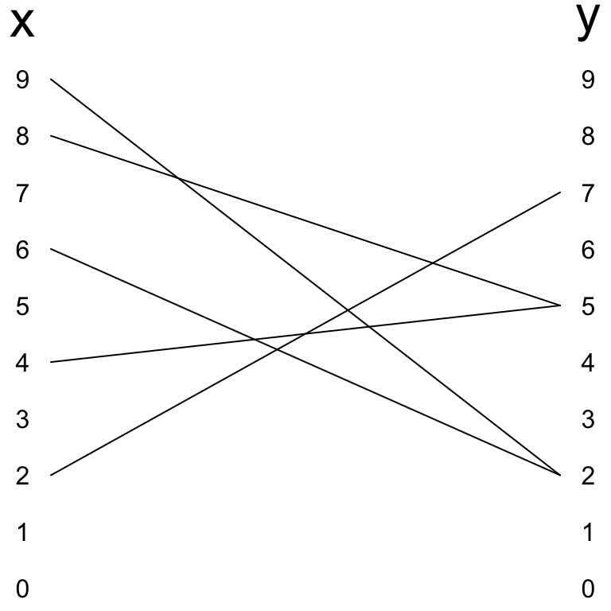

- Is $y$ a function of $x$?
- Is $x$ a function of $y$?
- Is there a one-to-one function?

# We do 4

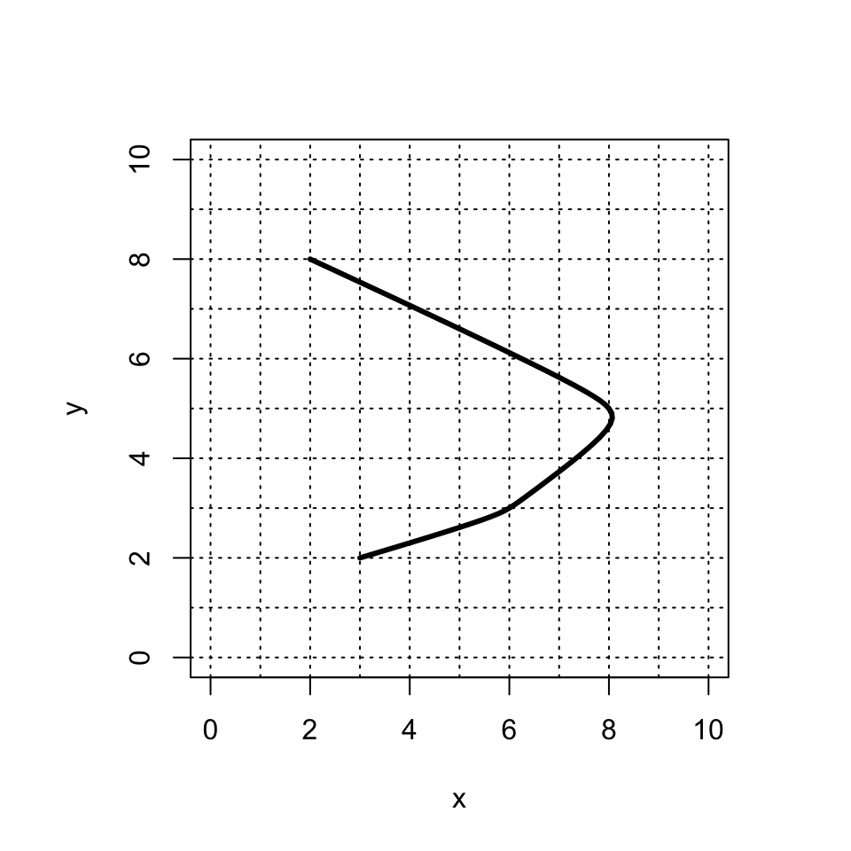

- Is $y$ a function of $x$?
- Is $x$ a function of $y$?
- Is there a one-to-one function?